# Motor Trend Analysis

Anthony Cato

April 24, 2017

## Summary

The goal of this analysis is to answer the following questions:

1. Is an automatic or manual transmission better for MPG?
2. Quantify the MPG difference between automatic and manual transmissions

The data source for this project comes from the **mtcars** dataset which is made available by default in R.

## Data Prep

#### Import data.table

```r
library(data.table, quietly = TRUE)
library(ggplot2, quietly = TRUE)
```

```r
data(mtcars)
mtcars$am <- as.factor(mtcars$am)
levels(mtcars$am) <- c("Automatic", "Manual")
mtcars <- as.data.table(mtcars)
```

## Hypothesis Testing

### Average MPG for each transmission type

```r
avg.trans <- mtcars[, .(avg_mpg = mean(mpg)), by = am]
names(avg.trans)[1] <- c("trans_typ")
avg.trans
```

```
##    trans_typ  avg_mpg
## 1:    Manual 24.39231
## 2: Automatic 17.14737
```

In comparing the miles per gallon for automatic and manual transmission cars, we observe that the average manual car in this dataset have better fuel economy than the automatic cars.

## T Test

```r
test <- t.test(mpg ~ am, data = mtcars)
test
```

```
##
##  Welch Two Sample t-test
##
## data:  mpg by am
## t = -3.7671, df = 18.332, p-value = 0.001374
## alternative hypothesis: true difference in means is not equal to 0
## 95 percent confidence interval:
##  -11.280194  -3.209684
## sample estimates:
## mean in group Automatic    mean in group Manual
##                17.14737                24.39231
```

Using the `t.test` function, we get a p-value of 0.0013736, indicating that there is strong evidence to reject the null hypothesis. In other words, a p-value this low suggests that there is a relationship between mpg and transmission type that is worth examining.

## Histogram and Boxplot of Mpgs

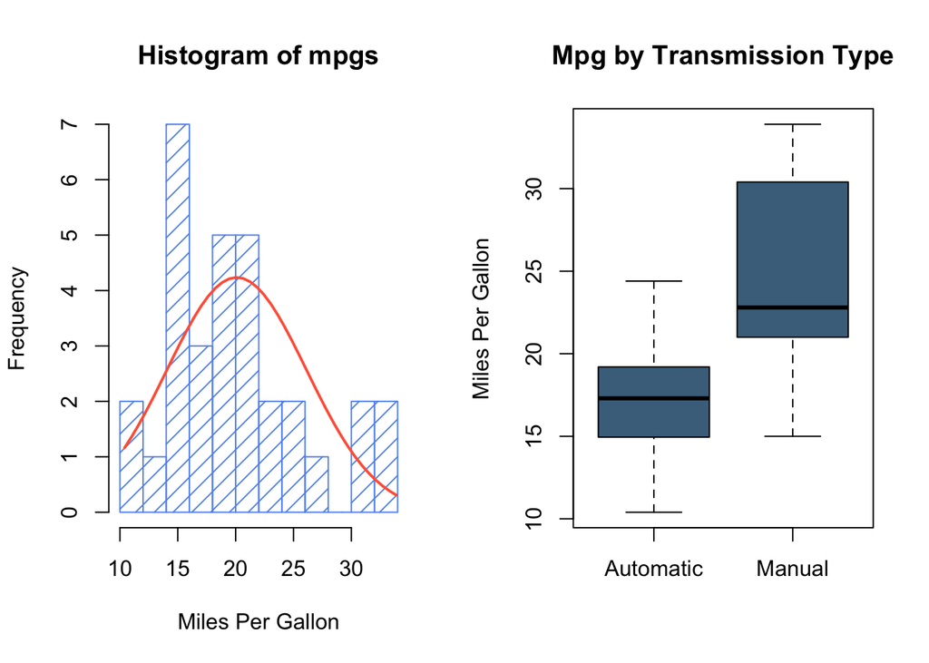

```r
par(mfrow = c(1, 2))
mpgs <- mtcars$mpg

h <- hist(mpgs,
          breaks = 10,
          density = 10,
          col = "cornflowerblue",
          xlab = "Miles Per Gallon")

xfit <- seq(min(mpgs), max(mpgs), length=40)
yfit <- dnorm(xfit, mean = mean(mpgs), sd = sd(mpgs))
yfit <- yfit * diff(h$mids[1:2]) * length(mpgs)
lines(xfit, yfit, col = "tomato", lwd = 2)

boxplot(mpg ~ am,
        data = mtcars,
        col = "skyblue4",
        ylab = "Miles Per Gallon",
        main = "Mpg by Transmission Type")
```

The histogram and overlaying distribution curve (on the left) reveals that mean the for mpg is `20.09` and its standard deviation is `6.03`. On the right, the boxplot illustration reaffirms the hypothesis that manual cars have better fuel economy.

## Simple Linear Regression

```r
fit <- lm(mpg ~ am, data = mtcars)
summary(fit)
```

```
##
## Call:
## lm(formula = mpg ~ am, data = mtcars)
##
## Residuals:
##     Min      1Q  Median      3Q     Max
## -9.3923 -3.0923 -0.2974  3.2439  9.5077
##
## Coefficients:
##             Estimate Std. Error t value Pr(>|t|)
## (Intercept)   17.147      1.125  15.247 1.13e-15 ***
## amManual       7.245      1.764   4.106 0.000285 ***
## ---
## Signif. codes:  0 '***' 0.001 '**' 0.01 '*' 0.05 '.' 0.1 ' ' 1
##
## Residual standard error: 4.902 on 30 degrees of freedom
## Multiple R-squared:  0.3598, Adjusted R-squared:  0.3385
## F-statistic: 16.86 on 1 and 30 DF,  p-value: 0.000285
```

A simple linear regression model shows that while transmission types have significant p-values, they are poor predictors of mpg. This poorness-of-fit is summarized by the adjusted r-squared of `0.3385`. This means that roughly `33.85`% of the variance in our data can be explained by this model. To get a better look at the relationship, we must include other variables. To this end, I’ve tested a few multivariate regression models to find the features that when combined serve as a better predictor of a car’s fuel economy.

## Multivariate Regression

```r
# Factoring in Transmission and Number of Cylinders
fit.cyl <- update(fit, mpg ~ am + factor(cyl))

# Factoring in Transmission, Number of Cylinders, and Weight
fit.cyl.wt <- update(fit.cyl, mpg ~ am + factor(cyl) + wt)

# Factoring in Transmission, Number of Cylinders, Weight, and Horsepower
fit.cyl.wt.hp <- update(fit.cyl.wt, mpg ~ am + factor(cyl) + wt + hp)
```

## Adjusted R Square for each model

```r
# Formula - mpg ~ am + factor(cyl)
summary(fit.cyl)$adj.r.squared
```

```
## [1] 0.7399447
```

```r
# Formula - mpg ~ am + factor(cyl) + wt
summary(fit.cyl.wt)$adj.r.squared
```

```
## [1] 0.8134405
```

```r
# Formula - mpg ~ am + factor(cyl) + wt + hp
summary(fit.cyl.wt.hp)$adj.r.squared
```

```
## [1] 0.8400875
```

```r
result <- round(summary(fit.cyl.wt.hp)$adj.r.squared, 4)
result.pct <- result * 100
```

## Conclusion

The third model, which explains how mpg is influenced by transmission type, number of cylinders, weight, and horsepower, yields the highest adjusted r_squared at **0.8401**. This r squared means that more than **84.01%** of the variance in our data can be explained by this model. Because of this high predictive accuracy, I would choose this model. For supporting plot, view section on residual plotting in the appendix.

## Appendix

### Residual Plotting for Best Model

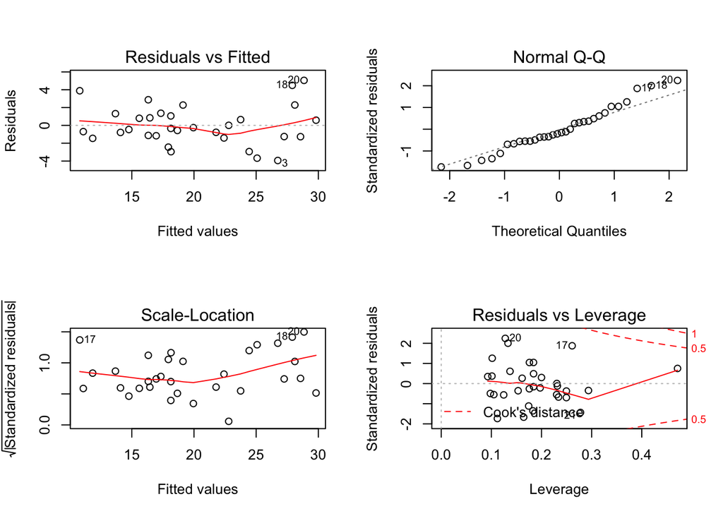

```r
par(mfrow = c(2,2))
plot(fit.cyl.wt.hp)
```

### Anova Comparison

```r
anova(fit, fit.cyl, fit.cyl.wt, fit.cyl.wt.hp)
```

```
## Analysis of Variance Table
##
## Model 1: mpg ~ am
## Model 2: mpg ~ am + factor(cyl)
## Model 3: mpg ~ am + factor(cyl) + wt
## Model 4: mpg ~ am + factor(cyl) + wt + hp
##   Res.Df    RSS Df Sum of Sq       F    Pr(>F)
## 1     30 720.90
## 2     28 264.50  2    456.40 39.2861 1.388e-08 ***
## 3     27 182.97  1     81.53 14.0354 0.0009026 ***
## 4     26 151.03  1     31.94  5.4991 0.0269346 *
## ---
## Signif. codes:  0 '***' 0.001 '**' 0.01 '*' 0.05 '.' 0.1 ' ' 1
```

The `anova` comparison shows that model 2 shows that much of the fluctuations in mpg can be explained by the transmission and type and number of cylinders as indicated by a r-squared of `0.7399`. The p-value, `1.3875174\times 10^{-8}` suggests that these two factors are a good starting point for the analysis.